# Homework2 - results

## Imports

```python
import numpy as np
import pandas as pd
import matplotlib.pyplot as plt
from matplotlib.lines import Line2D
import seaborn as sns

import torch
import torch.nn as nn
import torch.nn.functional as F
import torch.optim as optim

import torchvision
import torchvision.transforms as transforms

torch.set_printoptions(linewidth=120)
torch.set_grad_enabled(True)
```

```
<torch.autograd.grad_mode.set_grad_enabled at 0x7ff9ac180fd0>
```

## Load data and results

### Data

```python
train_set = torchvision.datasets.CIFAR10(
    root = './data/CIFAR',
    train = True,
#     download = True,
    transform = transforms.Compose([
        transforms.ToTensor()
    ])
)

test_set = torchvision.datasets.CIFAR10(
    root = './data/CIFAR',
    train = False,
#     download = True,
    transform = transforms.Compose([
        transforms.ToTensor()
    ])
)
```

### Nets

```python
class Block(nn.Module):
  expansion = 1

  def __init__(self, in_planes, planes, stride=1):
    super(Block, self).__init__()

    # define layers
    self.conv1 = nn.Conv2d(in_planes, planes, kernel_size=3, stride=stride, padding=1)
    self.bn1 = nn.BatchNorm2d(planes)

    self.conv2 = nn.Conv2d(planes, planes, kernel_size=3, stride=1, padding=1)
    self.bn2 = nn.BatchNorm2d(planes)

    self.shortcut = nn.Sequential()
    if stride != 1 or in_planes != self.expansion*planes:
      self.shortcut = nn.Sequential(
        nn.Conv2d(in_planes, self.expansion*planes, kernel_size=1, stride=stride),
        nn.BatchNorm2d(self.expansion*planes)
      )

  # define forward function
  def forward(self, x):
    # conv 1
    out = self.conv1(x)
    out = self.bn1(out)
    out = F.relu(out)

    # conv 2
    out = self.conv2(out)
    out = self.bn2(out)

    # shortcut
    out += self.shortcut(x)
    out = F.relu(out)

    return out
```

```python
class ResNet(nn.Module):
  def __init__(self, block, num_blocks, drop, num_classes=10):
    super(ResNet, self).__init__()
    self.in_planes = 64

    # define layers
    self.conv1 = nn.Conv2d(3, 64, kernel_size=3, stride=1, padding=1)
    self.bn1 = nn.BatchNorm2d(64)

    self.layer1 = self._make_layer(block, 64, num_blocks[0], stride=1)
    self.layer2 = self._make_layer(block, 128, num_blocks[1], stride=2)
    self.layer3 = self._make_layer(block, 256, num_blocks[2], stride=2)
    self.layer4 = self._make_layer(block, 512, num_blocks[3], stride=2)

    self.linear = nn.Linear(512*block.expansion, num_classes)
    self.dropout = nn.Dropout(p=drop)

  def _make_layer(self, block, planes, num_blocks, stride):
    strides = [stride] + [1]*(num_blocks-1)
    layers = []
    for stride in strides:
      layers.append(block(self.in_planes, planes, stride))
      self.in_planes = planes * block.expansion
    return nn.Sequential(*layers)

  # define forward function
  def forward(self, x):
    # conv
    out = self.conv1(x)
    out = self.bn1(out)
    out = F.relu(out)
    # resnet blocks
    out = self.layer1(out)
    out = self.dropout(out)
    out = self.layer2(out)
    out = self.dropout(out)
    out = self.layer3(out)
    out = self.dropout(out)
    out = self.layer4(out)
    out = self.dropout(out)

    out = F.avg_pool2d(out, 4)
    out = out.view(out.size(0), -1)
    out = self.linear(out)
    return out
```

```python
class ResNet18(ResNet):
  def __init__(self, drop):
    super(ResNet18, self).__init__(Block, [2, 2, 2, 2], drop=drop)


class ResNet34(ResNet):
  def __init__(self, drop):
    super(ResNet34, self).__init__(Block, [3, 4, 6, 3], drop=drop)
```

### Results

```python
results = pd.read_csv('results.csv', index_col=0)
results = results[results['run'].isin([1, 2, 3, 4, 9, 10, 11, 12])].reset_index(drop=True)
```

## Results

### Accuracy

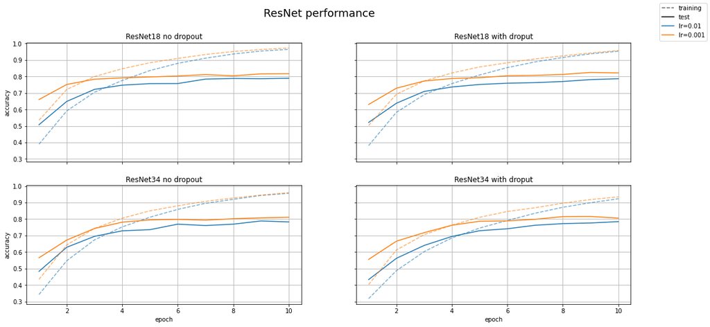

```python
fig, axs = plt.subplots(ncols=2, nrows=2, figsize=(18,8), sharex=True, sharey=True)
fig.suptitle('ResNet performance', fontsize=18)

for run, df in results.groupby(['run', 'lr', 'network', 'drop']):
    ax = (axs[0,0] if run[3]==0 else axs[0,1]) if run[2]=='ResNet18' else (axs[1,0] if run[3]==0 else axs[1,1])
    color = ('tab:blue' if run[1] == 0.01 else 'tab:orange')

    df.plot(x='epoch', y='accuracy', label='lr='+str(run[1]), ax=ax, color=color, linestyle='dashed', alpha=0.6)
    df.plot(x='epoch', y='test_accuracy', label='lr='+str(run[1]), ax=ax, color=color)

    ax.set_title(str(run[2]) + (' no dropout' if run[3]==0 else ' with droput'))
    ax.grid(visible=True)
    ax.get_legend().remove()

for ax in axs.flat:
    ax.set(ylabel='accuracy')

legend_lines = [Line2D([0], [0], color='k', linestyle='dashed', alpha=0.6, label='training'),
                Line2D([0], [0], color='k', label='test'),
                Line2D([0], [0], color='tab:blue', label='lr=0.01'),
                Line2D([0], [0], color='tab:orange', label='lr=0.001')]
fig.legend(handles=legend_lines, loc='upper right')

plt.show()
```

Looking at plots we can see that all nets trained to over 90% accuracy on the training set. However all nets were heavily overfitted and got olny around 80% accuracy on test set. Using dropout didn't really helped with overfitting. All nets got similar results, altough those trained with learning rate equal to 0.001 performed slightly better.

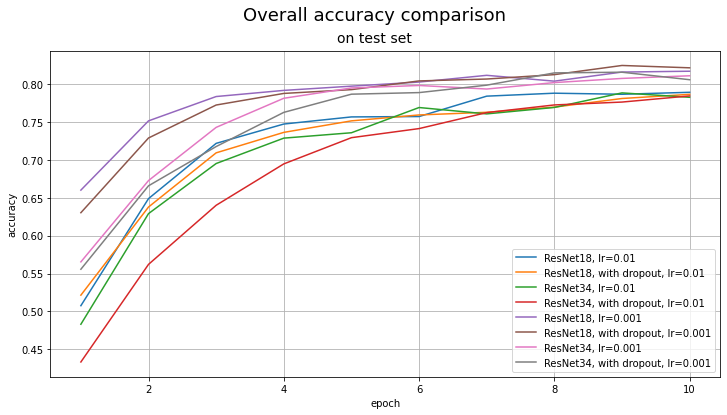

```python
fig, axs = plt.subplots(figsize=(12, 6))
fig.text(0.5, 0.95, 'Overall accuracy comparison', fontsize=18, ha='center')
fig.text(0.5, 0.9, 'on test set', fontsize=14, ha='center')

for run, df in results.groupby(['run', 'lr', 'network', 'drop']):
    df.plot(x='epoch',
            y='test_accuracy',
            label=run[2]+(', with dropout' if run[3]==0.1 else '')+', lr='+str(run[1]),
            ax=axs)
    axs.grid(True)

axs.set(ylabel='accuracy')
plt.show()
```

As we can see, after 10 epochs best accuracy on test set got ResNet18, with dropout and learning rate 0.001. In the next part of analysis we will focus on this net.

### Confusion

```python
net = ResNet18(drop=0.1)
net.load_state_dict(torch.load('./nets/run10.pth', map_location=torch.device('cpu')))
net.eval()
pass
```

```python
labs = test_set.targets
pred = []

loader = torch.utils.data.DataLoader(test_set, batch_size=500)
for batch in loader:
    inputs = batch[0]
    pred.extend(net(inputs).argmax(dim=1).numpy())
```

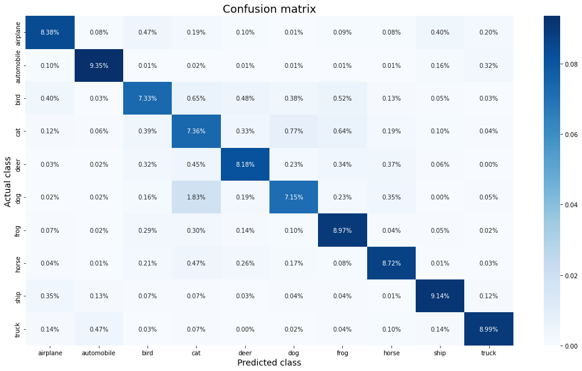

```python
from sklearn.metrics import confusion_matrix

cf_matrix = confusion_matrix(labs, pred)
fig, ax = plt.subplots(figsize=(18, 10))

sns.heatmap(cf_matrix/np.sum(cf_matrix), annot=True, fmt='.2%', cmap='Blues', ax=ax)
ax.set_title('Confusion matrix', fontsize=18)
ax.set_xlabel('Predicted class', fontsize=14)
ax.set_ylabel('Actual class', fontsize=14)

ax.xaxis.set_ticklabels(test_set.classes)
ax.yaxis.set_ticklabels(test_set.classes)

plt.show()
```

Looking at confusion matrix we can see that the most problem is to distinguish cats and dogs. But there are also some less noticeable problems with recognizing birds, airplanes and horses.

#### Interesting examples

```python
misclassified = []

for i in range(len(labs)):
    if labs[i] != pred[i]:
        misclassified.append(i)
```

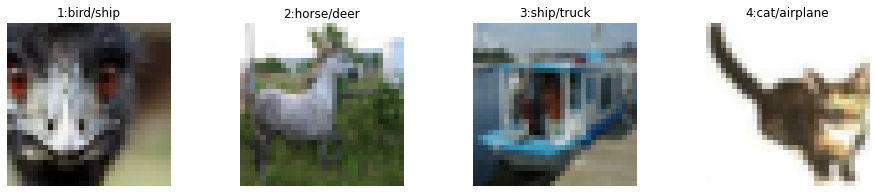

```python
interesting_examples = [35, 69, 306, 790]

fig, ax = plt.subplots(1, 4, figsize=(16, 3))
for i in range(len(interesting_examples)):
    n = interesting_examples[i]
    ax[i].imshow(test_set[n][0].permute(1, 2, 0))
    ax[i].axis(False)
    ax[i].set_title(f'{i+1}:{test_set.classes[labs[n]]}/{test_set.classes[pred[n]]}')
```

1. In the first picture there is a bird, but its bill looks a lot like a ship frontside.
2. In the second picture there is a horse, but it was confused with a deer. It is propably due to two vertical lines above its head which might have been mistaken with horns.
3. In the third picture there is a ship. Ship is clearly rectangular and stands next to the pavement which makes it look similar to a truck.
4. In the fourth picture there is a cat. Clearly a cat. But net for some reason misclassified it as an airplane

#### Reallife examples

I was also curious how net would classify my own picrures. So I made some photos of my house animals and looked at the results.

```python
from PIL import Image

images = []
for i in range(12):
    images.append(Image.open(f'./pictures/{i}.jpg'))
```

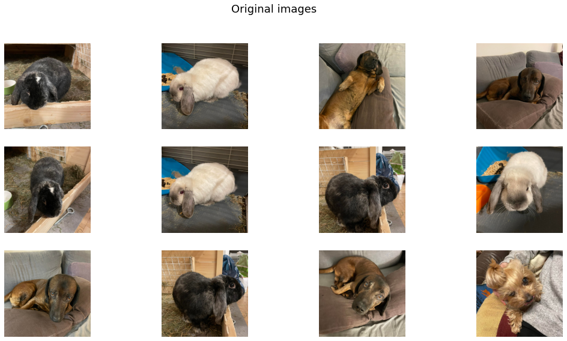

```python
fig, ax = plt.subplots((len(images)-1)//4+1, 4, figsize=(18, 3*((len(images)-1)//4+1)))
for i in range(len(images)):
    ax[i//4, i%4].imshow(images[i])
    ax[i//4, i%4].axis(False)

fig.suptitle('Original images', fontsize=18)
plt.show()
```

```python
for i in range(12):
    images[i] = torch.tensor(np.array(images[i].resize((32, 32)), dtype=np.float32)/256).permute(2, 0, 1)
```

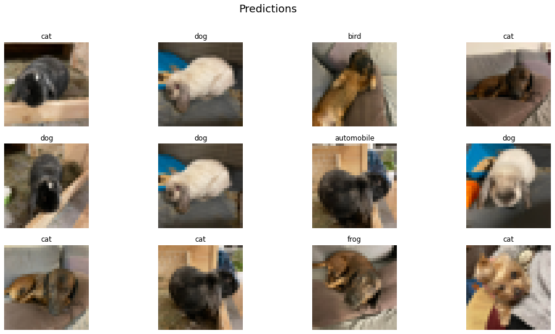

```python
fig, ax = plt.subplots((len(images)-1)//4+1, 4, figsize=(18, 3*((len(images)-1)//4+1)))
for i in range(len(images)):
    ax[i//4, i%4].imshow(images[i].permute(1, 2, 0))
    ax[i//4, i%4].axis(False)
    ax[i//4, i%4].set_title(test_set.classes[net(images[i].unsqueeze(0)).argmax(dim=1)])

fig.suptitle('Predictions', fontsize=18)
```

There were some pictures of rabbits (there is no such target class) and most of them were classified as dogs or cats, which was expected behaviour, but one was also signed as an automobile which was strange.

On the other hand, net did terrible job recognizing my dogs, and classified them mostly as cats, but sometimes also as a bird or a frog.

## Conclusion

Net has a relatively good performance, but makes some mistakes, especially when clasifing animals. More epochs would probably improve accuracy a lot.